# nwfscSurvey

Chantel Wetzel

2018-07-26

## Introduction

The **nwfscSurvey** package was written by scientists at the Northwest Fisheries Science Center (NWFSC) to explore and process survey composition data for use in assessments. The package can be used for the NWFSC shelf-slope survey, the NWFSC slope survey, the AFSC slope survey, and the Triennial survey. The package included functions that query the NWFSC data warehouse (https://www.nwfsc.noaa.gov/data) and process the data for use in West Coast stock assessments

## Use

The **nwfscSurvey** can be used to create:

- Pull data from the NWFSC data warehouse
- Calculate the design based indices based upon pre-specified stratification.
- Create length composition data expanded by the design-based indices for use in Stock Synthesis.
- Create age-composition data expanded by the design-based indices for use in Stock Synthesis.
- Create conditional age-at-length composition data for used in Stock Synthesis
- Create plots to visualize the data; design-based index plots, bubble plots of length and age data, sex ratio.

## Functions

A list of all functions in the packages can be viewed by:

```r
ls("package:nwfscSurvey")
```

## Examples

### NWFSC shelf-slope bottom trawl survey

#### Pull data

Pull both the catch and biological data:

```r
catch = PullCatch.fn(Name = "Pacific ocean perch",
                     SurveyName = "NWFSC.Combo",
                     ...)
bio   = PullBio.fn(Name = "Pacific ocean perch",
                   SurveyName = "NWFSC.Combo",
                   ...)
```

#### Index of abundance

Define the stratification:

```r
strata = CreateStrataDF.fn(names=c("shallow_s", "mid_s", "deep_s","shallow_n", "mid_n", "deep_n"),
                           depths = c(55, 200, 300, 549),
                           lats = c(32, 42, 49))
```

Calculate the design based index of abundance:

```r
biomass = Biomass.fn(dir = getwd(),
                     dat = catch,
                     strat.df = strata,
                     printfolder = "forSS",
                     outputMedian = TRUE)
```

The function returns a list with the second element containing the design-based estimates by year:

| Year | Season | Fleet | Value | seLogB |
| --- | --- | --- | --- | --- |
| 2003 | 1 | EnterFleet | 21055083 | 0.357 |
| … |  |  |  |  |
| 2015 | 1 | EnterFleet | 9766200 | 0.563 |

Plot the design based index of abundance:

```r
PlotBio.fn(dir = getwd(),
           dat = biomass,
           main = "NWFSC shelf-slope bottom trawl survey",
           ...)
```

The Biomass.fn returns a list with the second element containing the design-based index of abundance. The design based index is calculated based on the defined stratas. The function writes a csv file inside the dir input location to a “forSS” folder. The PlotBio.fn plots the calculated design based index from the Biomass.fn. If the dopng is set to true a “plot” folder will be created in the directory location and a png of the plot will be saved.

The plot of the design-based index of abundance:

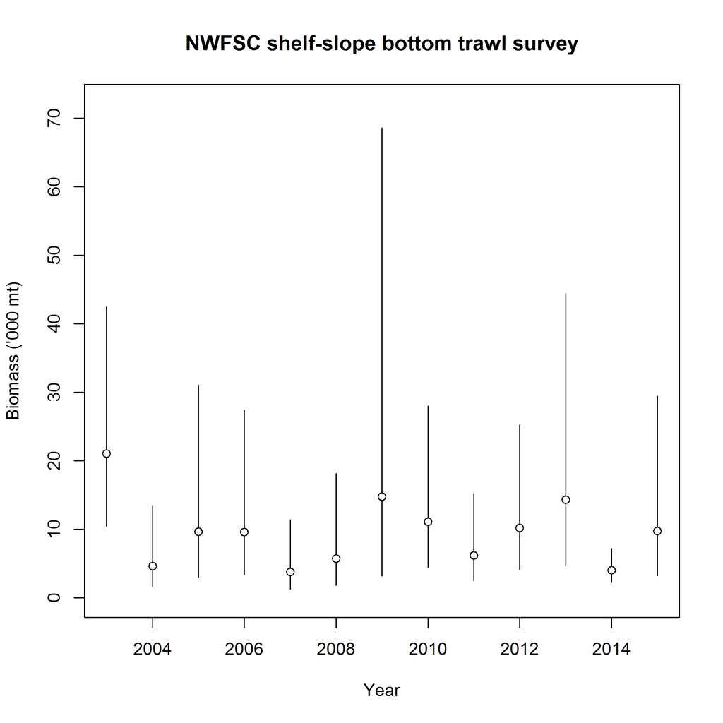

#### Length composition data

A function to calculate the input sample size based on Stewart & Hamel (2014) which determined that the input sample size was related to the species group (flatfish, shelf rockfish, slope rockfish, thornyhead, others, or all groups) and number of tows. The function writes a csv file with the “forSS” folder containing the number of tows and observed fish by year.

```r
n = GetN(dir = getwd(),
         dat = bio,
         type = "length",
         species = "shelfrock")
```

The SurveyLFs.fn calculates and formats the length composition data for Stock Synthesis:

```r
Lengths <- SurveyLFs.fn(dir = getwd(),
                        datL =  bio,
                        datTows = catch,
                        strata.df = strata,
                        lgthBins = len.bins,
                        gender = 3,
                        ...)
```

The above call will calculate the length frequencies for use in Stock Synthesis and write the files inside the “forSS” folder. The example call does not assign unsexed fish to the sexed length comps but will produce csv files for both the sexed and unsexed fish. If you would like to assign the unsexed fish to a sex based on the sex ratio the user will need to specificy the sex ratio value (sexRatioUnsexed) to use for fish under a specified size (maxSizeUnsexed) where unsexed fish greater than the specified size will be assign based on the sex ratio from other observations.

There are many inputs to the SurveyLFs.fn, please look over the function inputs to explore additional ways to process the data.

To plot the length frequency data:

```r
PlotFreqData.fn(dir = getwd(),
                dat = Lengths,
                ylim = c(0,50),
                yaxs = "i",
                ylab = "Length (cm)",
                dopng = TRUE,
                ...)
```

If the dopng is set to true a “plot” folder will be created in the directory location and a png of the plot will be saved:

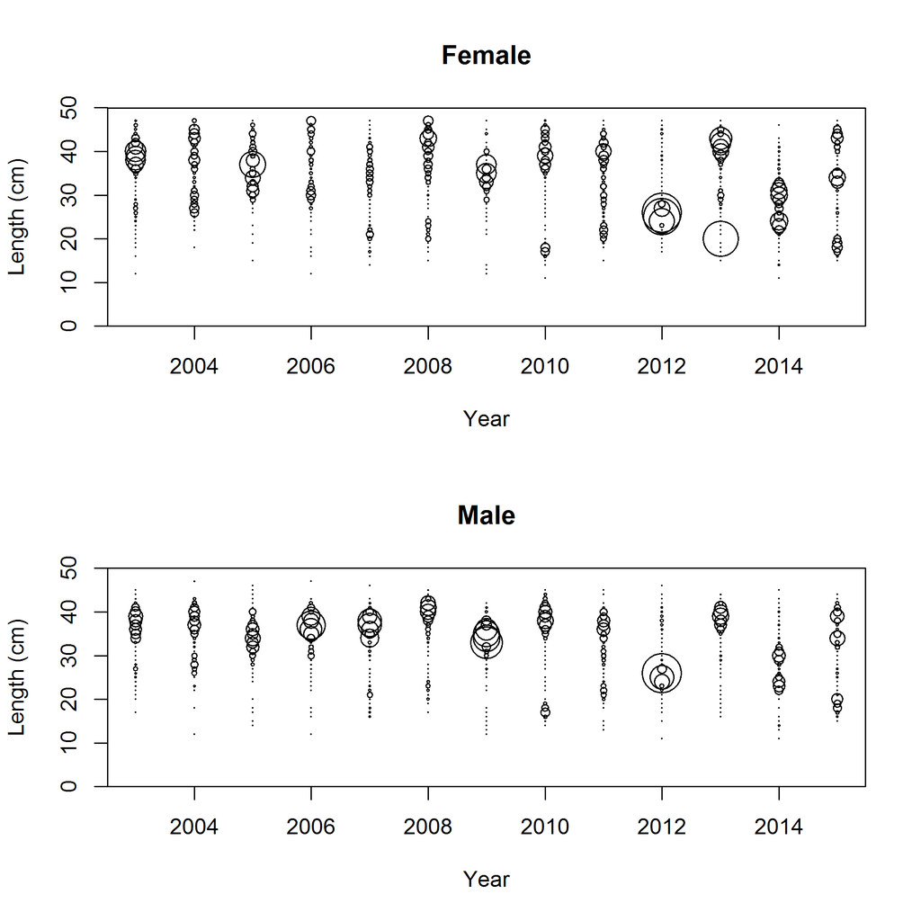

#### Marginal age composition data

Calculate the marginal age sample size:

```r
n = getN(dir = getwd(),
         dat = bio,
         type = "age",
         species = "shelfrock")
```

The SurveyAFs.fn calculates and formats the age composition data for Stock Synthesis:

```r
Ages <- SurveyAFs.fn(dir = getwd(),
                     datA = bio,
                     datTows = catch,
                     strat.df = strata,
                     ageBins = age.bins,
                     gender = 3,
                     nSamps = n,
                     ...)
```

To plot the age frequency data:

```r
PlotFreqData.fn(dir = getwd(),
                dat = Ages,
                ylim = c(0,100),
                ylab = "Age",
                dopng = TRUE,
                ...)
```

If the dopng is set to true a “plot” folder will be created in the directory location and a png of the plot will be saved.

#### Conditional-age-at-length data

To calculate conditional-age-at-length data formatted for SS:

```r
CAAL <- SurveyAgeAtLen.fn(dir = getwd(),
                          datAL = bio,
                          datTows = catch,
                          strata.df = strata,
                          lgthBins = len.bins,
                          ageBins = age.bins,
                          ...)
```

Creates unexpanded conditional-age-at-length data for both sexes with input sample sizes based on the observed number of fish in each length bin by year.

#### Additional data visualization

There are a couple of additional plotting function that are included in the package: PlotVarLengthAtAge.fn and PlotSexRatio.fn.